# Test RISC on simulations data with groups and lineages

Martin Loza

On this workflow I will correct batch-effect on the Figure 4 dataset described in the Canek paper. This test asses the ability of the the tool to correct-batch effect on multi-datasets integrations with just a few cells shared among batches.

```r
library(Seurat)
library(RISC)
library(ggplot2)
library(splatter)
library(patchwork)
library(here)
source(here("ScRNASeq/BatchCorrection/Functions.R"))
seed = 321

set.seed(seed)
mytheme <- theme_classic() + theme(text = element_text(size = 20))
theme_set(mytheme)
testName <- "Pseudo-batches"

options(future.globals.maxSize = 4e10)

knitr::opts_chunk$set(
    fig.align = "center",
    fig.height = 5,
    fig.width = 10
)
```

# Load data with Splatter

On this test I will use a pre-processed dataset from the Figure 4 workflow of Canek’s paper.

```r
Uncorrected <- readRDS(file = here("Data/CanekPaper/Results/Figure4/Uncorrectedv2.Rds"))
Uncorrected
```

```
An object of class Seurat
1999 features across 3610 samples within 1 assay
Active assay: RNA (1999 features, 1999 variable features)
 2 dimensional reductions calculated: pca, umap
```

# Correct-batch effects

We use the wrapper function from the Functions.R file

```r
x <- RunRISC(Uncorrected = Uncorrected, batch = "batch")
x
```

```
An object of class Seurat
3960 features across 3426 samples within 2 assays
Active assay: integrated (1980 features, 0 variable features)
 1 other assay present: RNA
 2 dimensional reductions calculated: pca, umap
```

# Visualization

Once we get our Seurat objects with the corrected assay, we perform PCA and choose the number of dimensions by looking at the elbow plot of the standard deviation of the principal components. On this case we think that 10 dimensions would be enough to capture the majority of information from our integrated dataset.

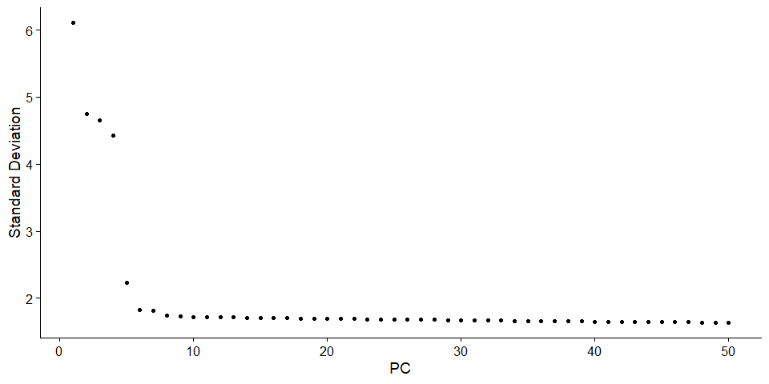

```r
set.seed(seed)
VariableFeatures(x) <- rownames(x)
x <-  ScaleData(x, verbose = FALSE)
x <- RunPCA(x, npcs = 50, verbose = FALSE)
ElbowPlot(x, ndims = 50)
```

We then run umap using the first 10 dimensions from PCA

```r
set.seed(seed)
x <- RunUMAP(x, reduction = "pca", dims = 1:10, verbose = FALSE)
```

```
The default method for RunUMAP has changed from calling Python UMAP via reticulate to the R-native UWOT using the cosine metric
To use Python UMAP via reticulate, set umap.method to 'umap-learn' and metric to 'correlation'
This message will be shown once per session
```

# Plots

Finally we can plot our data and color the cells by group and batch to visually verify the mixing among batches.

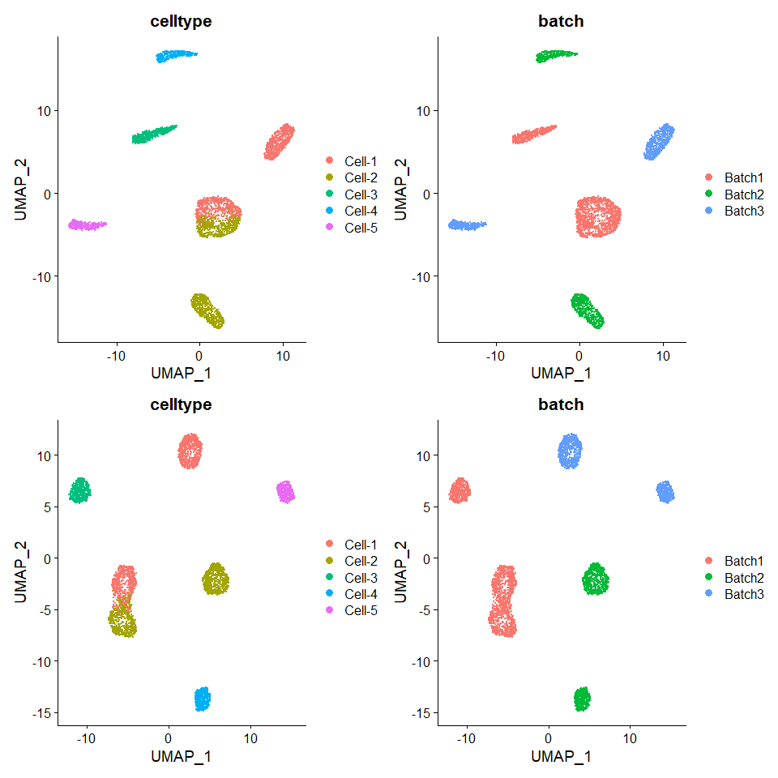

```r
Seurat::DimPlot(x, group.by = "celltype") + Seurat::DimPlot(x, group.by = "batch") +
  Seurat::DimPlot(Uncorrected, group.by = "celltype") + Seurat::DimPlot(Uncorrected, group.by = "batch") + mytheme
```

CONCLUSIONS: On this scenario, RISC was not able to correct the batch-effects, as we can observed by the distance among same cell-types on the UMAP representation. Moreover, as stated on previous tests, RISC seemed to affect the original distribution of the groups, as can be observed by the “deformation”elongated" cells groups after correction.

.